# Reproducible Research: Peer Assessment 1

Ferdinand DeRamos

Sunday, May 17, 2015

## Set global settings for this markdown.

```r
echo = TRUE  ## This makes code visible.
options(scipen = 1)  ## Disable a number's scientific notation.
```

## Pre-processing and reading of input data.

```r
unzip("activity.zip", exdir = "./reproducible_research")
input_data <- read.csv("./reproducible_research/activity.csv",
                       colClasses = c("integer", "Date", "factor"))
input_data$month <- as.numeric(format(input_data$date, "%m"))
NA_free <- na.omit(input_data)
rownames(NA_free) <- 1:nrow(NA_free)
head(NA_free)
```

```
##   steps       date interval month
## 1     0 2012-10-02        0    10
## 2     0 2012-10-02        5    10
## 3     0 2012-10-02       10    10
## 4     0 2012-10-02       15    10
## 5     0 2012-10-02       20    10
## 6     0 2012-10-02       25    10
```

```r
dim(NA_free)
```

```
## [1] 15264     4
```

```r
library(ggplot2)
```

## Mean total number of steps taken per day?

Ignore the missing values in the dataset.

- Histogram of total number of steps taken each day.

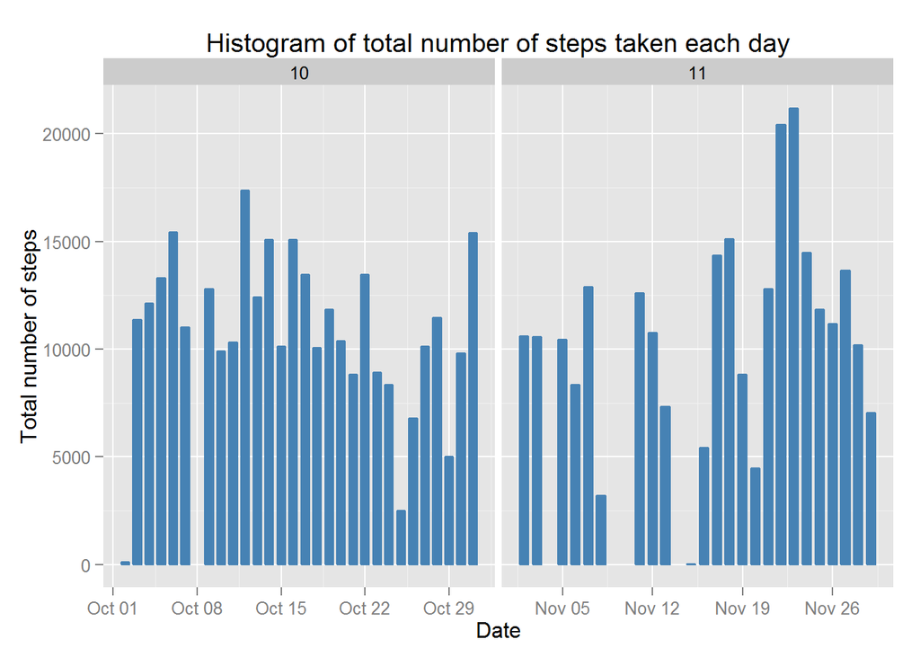

```r
ggplot(NA_free, aes(date, steps)) + geom_bar(stat = "identity", colour = "steelblue", fill = "steelblue", width = 0.7) + facet_grid(. ~ month, scales = "free") + labs(title = "Histogram of total number of steps taken each day", x = "Date", y = "Total number of steps")
```

- Determine the mean and median total number of steps taken per day.

Mean total number of steps taken each day:

```r
total_steps <- aggregate(NA_free$steps, list(Date = NA_free$date), FUN = "sum")$x
mean(total_steps)
```

```
## [1] 10766.19
```

Median total number of steps taken each day.

```r
median(total_steps)
```

```
## [1] 10765
```

## Average daily activity pattern.

- Make a time series plot (i.e. type = “l”) of the 5-minute interval (x-axis) and the average number of steps taken, averaged across all days (y-axis)

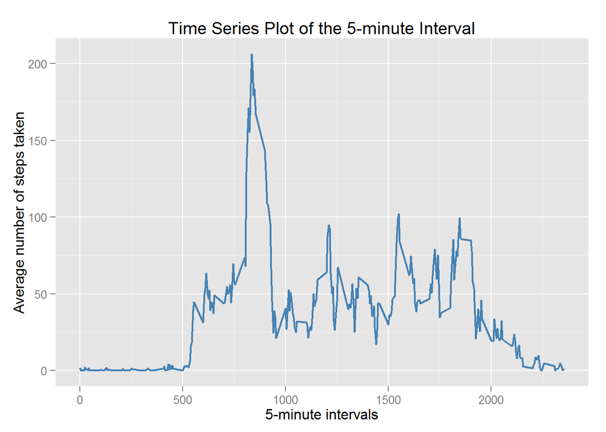

```r
avg_steps <- aggregate(NA_free$steps, list(interval = as.numeric(as.character(NA_free$interval))), FUN = "mean")
names(avg_steps)[2] <- "mean_of_steps"

ggplot(avg_steps, aes(interval, mean_of_steps)) + geom_line(color = "steelblue", size = 0.8) + labs(title = "Time Series Plot of the 5-minute Interval", x = "5-minute intervals", y = "Average number of steps taken")
```

- Determine which 5-minute interval, on average across all the days in the dataset, contains the maximum number of steps.

```r
avg_steps[avg_steps$mean_of_steps == max(avg_steps$mean_of_steps), ]
```

```
##     interval mean_of_steps
## 104      835      206.1698
```

```r
sum(is.na(data))
```

```
## [1] 0
```

- Find missing values in the dataset using the mean/median for that day, or the mean for that 5-minute interval, etc.

The mean for 5-minute interval is used to fill in each NA value in the steps column.

- Create a new dataset based on original dataset with missing data determined and provided.

```r
new_data <- input_data
for (i in 1:nrow(new_data)) {
    if (is.na(new_data$steps[i])) {
        new_data$steps[i] <- avg_steps[which(new_data$interval[i] == avg_steps$interval), ]$mean_of_steps
    }
}

head(new_data)
```

```
##       steps       date interval month
## 1 1.7169811 2012-10-01        0    10
## 2 0.3396226 2012-10-01        5    10
## 3 0.1320755 2012-10-01       10    10
## 4 0.1509434 2012-10-01       15    10
## 5 0.0754717 2012-10-01       20    10
## 6 2.0943396 2012-10-01       25    10
```

```r
sum(is.na(new_data))
```

```
## [1] 0
```

- Generate histogram of total number of steps taken each day, and calculate and report mean and median total number of steps taken per day.

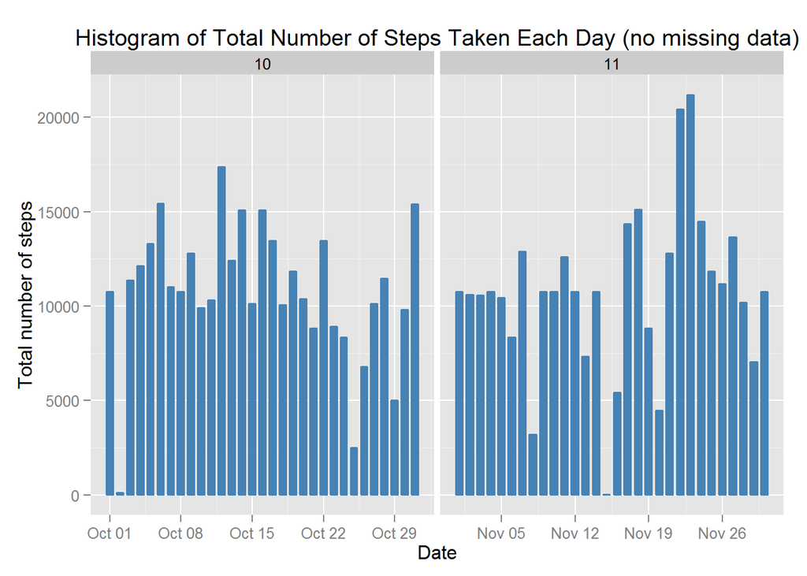

```r
ggplot(new_data, aes(date, steps)) + geom_bar(stat = "identity",
       colour = "steelblue", fill = "steelblue",  width = 0.7) + facet_grid(. ~ month, scales = "free") + labs(title = "Histogram of Total Number of Steps Taken Each Day (no missing data)", x = "Date", y = "Total number of steps")
```

- Figure out whether values differ from estimates of assignment’s first part. Explain the impact of inputting missing data on estimates of total daily number of steps.

Calculate mean total number of steps taken per day:

```r
newtotal_steps <- aggregate(new_data$steps,
                           list(Date = new_data$date),
                           FUN = "sum")$x
new_mean <- mean(newtotal_steps)
new_mean
```

```
## [1] 10766.19
```

Median total number of steps taken per day:

```r
new_median <- median(newtotal_steps)
new_median
```

```
## [1] 10766.19
```

Compare new data with first two observations before inputting missing data:

```r
old_mean <- mean(total_steps)
old_median <- median(total_steps)
new_mean - old_mean
```

```
## [1] 0
```

```r
new_median - old_median
```

```
## [1] 1.188679
```

Providing missing data, the new mean of total steps taken per day remains the same as the old mean but the new median of total steps taken per day is greater than the old median.